# Data Mining: Titanic(2)

從(1)中看到了類別變數的一些概況，延續下去我想看看**Survived**跟這些類別變數的關係， 雖然說是資料探勘啦，但當然還是從簡單畫圖開始，哈哈QQ。

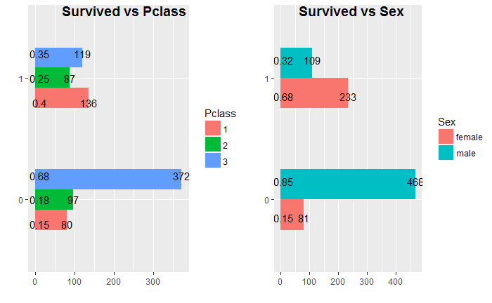

**Survived vs Pclass**

- **3**階層人數最多死得也最多，死掉的人當中有68%來自這個階層。
- **1**階層人數最後活著的人數最多，存活下來當中有40%來自這個階層。

**Survived vs Sex**

- 存活下來的人當中有68%是女性。
- 死亡的人當中有85%來自男性。

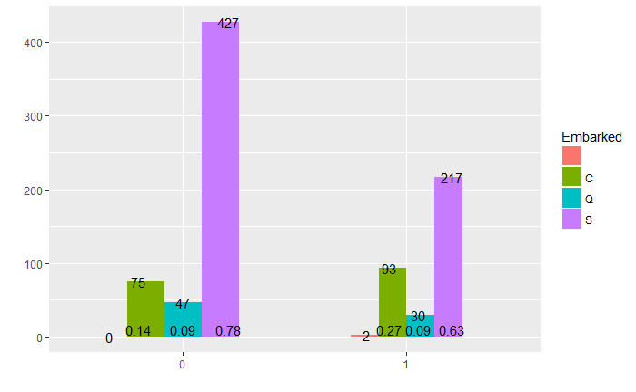

**Survived vs Embarked**